# week 4 lab

Generation date: mei 17, 2018 - 13:30:02

```r
mydf <- read.csv("lab4_cheese.csv") # load data
str(mydf)
```

```
## 'data.frame':    30 obs. of  6 variables:
##  $ X     : int  1 2 3 4 5 6 7 8 9 10 ...
##  $ case  : int  1 2 3 4 5 6 7 8 9 10 ...
##  $ acetic: num  4.54 5.16 5.37 5.76 4.66 ...
##  $ h2s   : num  3.13 5.04 5.44 7.5 3.81 ...
##  $ lactic: num  0.86 1.53 1.57 1.81 0.99 1.09 1.29 1.78 1.29 1.58 ...
##  $ taste : num  12.3 20.9 39 47.9 5.6 25.9 37.3 21.9 18.1 21 ...
```

```r
acetic <- mydf$acetic
lactic <- mydf$lactic
h2s <- mydf$h2s
taste <- mydf$taste
```

# 1 Scatter plots

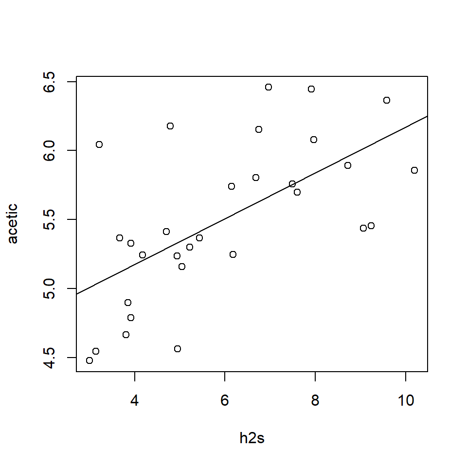

```r
plot(acetic ~ h2s)
abline(lm(acetic ~ h2s))
```

```r
cor.test(acetic, h2s, method="spearman")
```

```
##
##  Spearman's rank correlation rho
##
## data:  acetic and h2s
## S = 1586.4, p-value = 0.0001113
## alternative hypothesis: true rho is not equal to 0
## sample estimates:
##      rho
## 0.647085
```

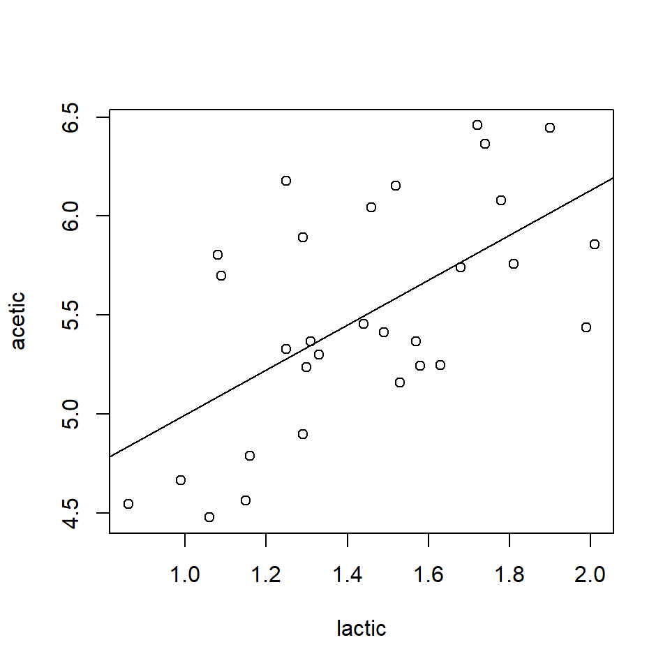

```r
plot(acetic ~ lactic)
abline(lm(acetic ~ lactic))
```

```r
cor.test(acetic, lactic, method="spearman")
```

```
##
##  Spearman's rank correlation rho
##
## data:  acetic and lactic
## S = 1992.2, p-value = 0.001395
## alternative hypothesis: true rho is not equal to 0
## sample estimates:
##       rho
## 0.5568043
```

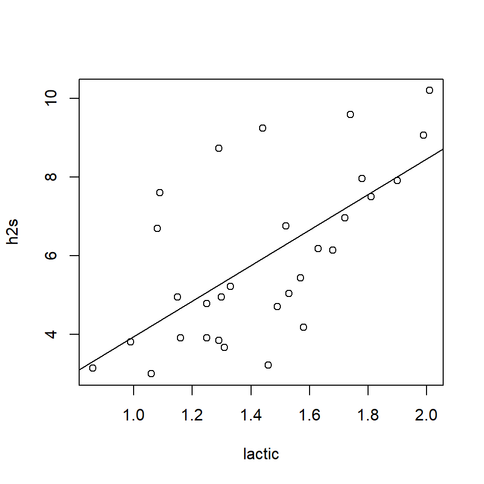

```r
plot(h2s ~ lactic)
abline(lm(h2s ~ lactic))
```

```r
cor.test(h2s, lactic, method="spearman")
```

```
##
##  Spearman's rank correlation rho
##
## data:  h2s and lactic
## S = 1661.6, p-value = 0.0001888
## alternative hypothesis: true rho is not equal to 0
## sample estimates:
##      rho
## 0.630355
```

I used the Spearman method. This is because the Pearson assumption aren’t met where as the Spearman is. The assumptions are:

Randomly selected sample

Ordinal scale variables

The p-values are as follows:

1. P-level = 0.0001113 rho = 0.647085
2. P-level = 0.001395 rho = 0.5568043
3. P-level = 0.0001888 rho = 0.630355

All the p-level states that there are significance correlations. The rho level states they are also positive.

# 2 LR

```r
(summary(m <- lm(taste ~ acetic + h2s + lactic)))
```

```
##
## Call:
## lm(formula = taste ~ acetic + h2s + lactic)
##
## Residuals:
##     Min      1Q  Median      3Q     Max
## -17.390  -6.612  -1.009   4.908  25.449
##
## Coefficients:
##             Estimate Std. Error t value Pr(>|t|)
## (Intercept) -28.8768    19.7354  -1.463  0.15540
## acetic        0.3277     4.4598   0.073  0.94198
## h2s           3.9118     1.2484   3.133  0.00425 **
## lactic       19.6705     8.6291   2.280  0.03108 *
## ---
## Signif. codes:  0 '***' 0.001 '**' 0.01 '*' 0.05 '.' 0.1 ' ' 1
##
## Residual standard error: 10.13 on 26 degrees of freedom
## Multiple R-squared:  0.6518, Adjusted R-squared:  0.6116
## F-statistic: 16.22 on 3 and 26 DF,  p-value: 3.81e-06
```

Acetic: p-level = 0.94198 No significance is found

H2s: p-level = 0.00425 Significance is found

Lactic: p-level = 0.03108 Significance is found

If the h2s variable is increased the taste variable wil increase by four. (taste = h2s <|> 4 = 1)

If the lactic variable is increased the taste variable wil increase by twenty. (taste = lactic <|> 20 = 1)

# 3 Interactions

Try all the possible interactions between pairs of predictors and plot the model in which the coefficient of the interaction has the lowest p-value. If the model includes acetic in the interaction use this vtariable as the modifier (attribute “by” or “modx” depending on the plot function you use). How do you interpret the plot? Is the interaction significant?

```r
summary(m1 <- lm(taste ~ h2s * acetic + lactic))$coefficients
```

```
##               Estimate Std. Error    t value   Pr(>|t|)
## (Intercept)  28.817217  58.608236  0.4916923 0.62722644
## h2s          -7.575347  11.060654 -0.6848914 0.49971369
## acetic      -10.328044  11.124418 -0.9284121 0.36207162
## lactic       20.913225   8.695413  2.4050871 0.02389637
## h2s:acetic    2.016993   1.929733  1.0452188 0.30592343
```

```r
summary(m2 <- lm(taste ~ h2s * lactic + acetic))$coefficients
```

```
##                Estimate Std. Error    t value  Pr(>|t|)
## (Intercept) -24.3506028  29.305323 -0.8309276 0.4138803
## h2s           2.8666820   5.084371  0.5638224 0.5778983
## lactic       14.9374071  23.964091  0.6233246 0.5387170
## acetic        0.7547105   4.969102  0.1518807 0.8805001
## h2s:lactic    0.6868853   3.235220  0.2123149 0.8335830
```

```r
summary(m3 <- lm(taste ~ lactic * acetic + h2s))$coefficients
```

```
##                 Estimate Std. Error    t value    Pr(>|t|)
## (Intercept)    67.020128  83.790490  0.7998536 0.431330625
## lactic        -51.891883  61.395507 -0.8452065 0.406012270
## acetic        -17.229320  15.558531 -1.1073873 0.278667915
## h2s             3.883383   1.239511  3.1329973 0.004376877
## lactic:acetic  12.951901  11.003138  1.1771098 0.250237424
```

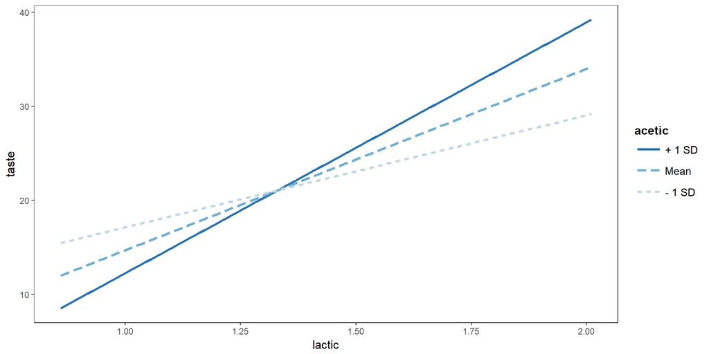

```r
interact_plot(m3, pred = lactic, modx = acetic)
```

h2s ~ acetic: p-level = 0.30592343

h2s ~ lactic: p-level = 0.8335830

lactic ~ acetic: p-level = 0.250237424

The lowest p-level is the interaction between lactic and acetic.

If there is a low level of lactic it is better to add less acetic to better the taste level. If we surpass the lactic level of 1.35 it is better to add more acetic to better the taste level.

# 4 Assumption: Linear relationship

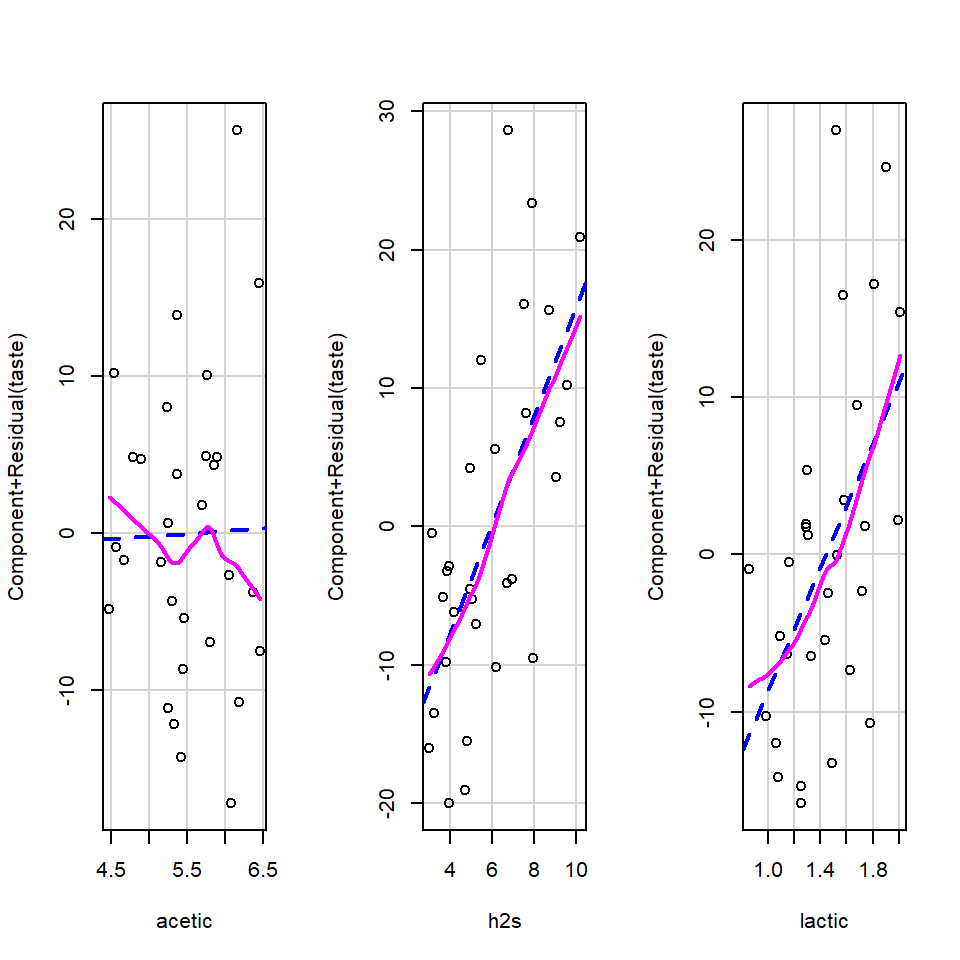

```r
par(mfrow = c(1,3))
crPlot(m, var = "acetic")
crPlot(m, var = "h2s")
crPlot(m, var = "lactic")
```

In the plot you can see that h2s and lactic have a relation. The response variable also roughly linear. The acetic variable on the other hand is not even near to linear.

# 5 Assumption: Errors vary constantly (homoscedasticity)

$H_0$: the error has constant variance with the response

$H_a$: the error has no constant variance with the response

```r
ncvTest(m)
```

```
## Non-constant Variance Score Test
## Variance formula: ~ fitted.values
## Chisquare = 1.157465    Df = 1     p = 0.2819919
```

```r
ncvTest(m, ~ acetic)
```

```
## Non-constant Variance Score Test
## Variance formula: ~ acetic
## Chisquare = 3.885577    Df = 1     p = 0.04870253
```

```r
ncvTest(m, ~ h2s)
```

```
## Non-constant Variance Score Test
## Variance formula: ~ h2s
## Chisquare = 0.5192075    Df = 1     p = 0.4711799
```

```r
ncvTest(m, ~ lactic)
```

```
## Non-constant Variance Score Test
## Variance formula: ~ lactic
## Chisquare = 1.687486    Df = 1     p = 0.1939326
```

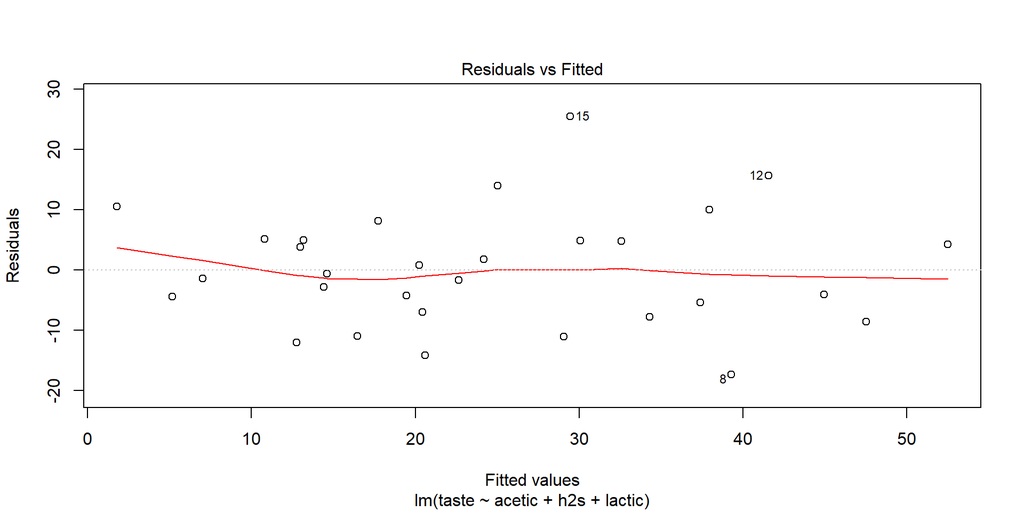

```r
plot(m, which=1)
```

m only: p-level = 0.2819919

acetic: p-level = 0.04870253

h2s: p-level = 0.4711799

lactic: p-level = 0.1939326

If use all variables together the p-level is not significant and therefor we cannot reject $H_0$. This means the error has constant variance with the response.

If we explore the variables one for one we see that we can’t reject the $H_0$ for h2s and lactic. However for acetic we must reject $H_0$ and accept $H_a$. This means the error has no constant variance with the response.

# 6 Assumption: Multicollinearity

```r
car::vif(m)
```

```
##   acetic      h2s   lactic
## 1.831589 1.992200 1.937912
```

Scores: acetic = 1.831589 h2s = 1.992200 lactic = 1.937912

All the scores are below 5. We must conclude that there is no multicollinearity.

# 7 Assumption: autocorrelation of residuals

$H_0$: There is no autocorrelation between the residuals.

$H_a$: There is an autocorrelation between the residuals.

```r
durbinWatsonTest(m) # h0: no autocorrelation
```

```
##  lag Autocorrelation D-W Statistic p-value
##    1       0.1692325       1.57513   0.176
##  Alternative hypothesis: rho != 0
```

The p-level is above the significance level and so we must conclude we cannot reject $H_0$. This means there is no autocorrelation between the residuals.

# 8 Assumption: residuals normally distributed

$H-0$ = Each residual follows normal distribution.

$H-a$ = Each residual doesn’t follow normal distribution.

```r
shapiro.test(residuals(m))
```

```
##
##  Shapiro-Wilk normality test
##
## data:  residuals(m)
## W = 0.98021, p-value = 0.8312
```

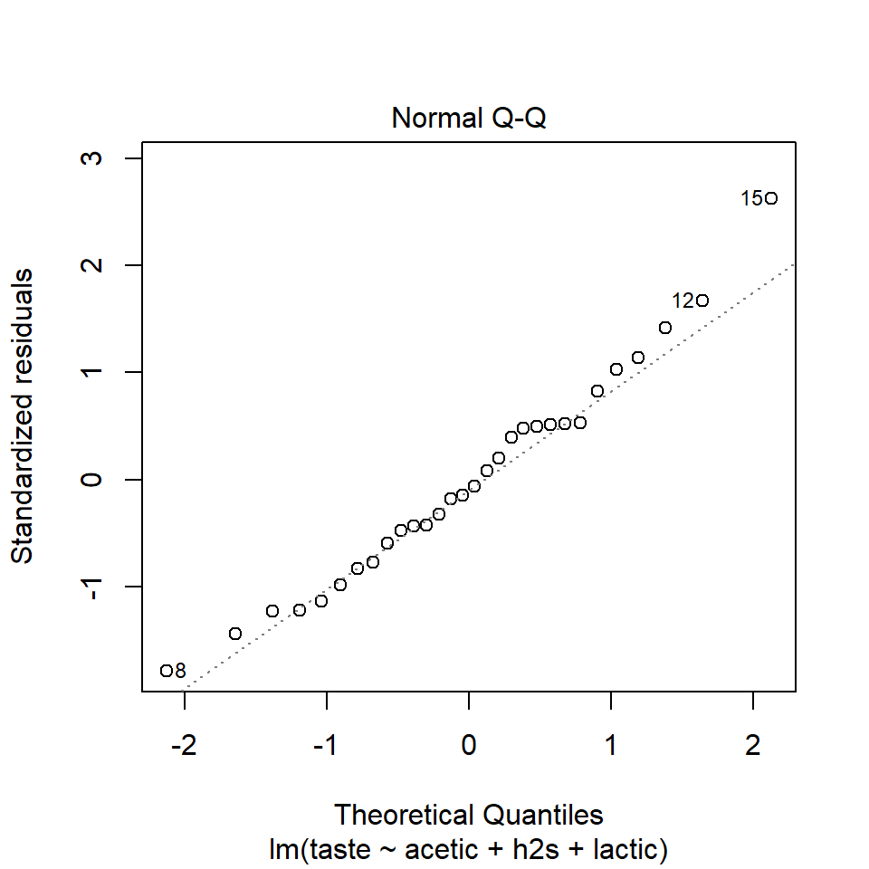

```r
plot(m, which = 2)
```

p-level = 0.8312

The p-level is above the significance level. Therefore we cannot reject $H_0$. This means every residual follows a normal distribution.

We can see in the plot that this is also confirms a normal distribution.

# 9 Variable selection

```r
m0 <- lm(taste ~ 1, data = mydf)
mforward <- step(m0, direction = "forward", scope = ~ acetic + h2s + lactic)
```

```
## Start:  AIC=168.29
## taste ~ 1
##
##          Df Sum of Sq    RSS    AIC
## + h2s     1    4376.7 3286.1 144.89
## + lactic  1    3800.4 3862.5 149.74
## + acetic  1    2314.1 5348.7 159.50
## <none>                7662.9 168.29
##
## Step:  AIC=144.89
## taste ~ h2s
##
##          Df Sum of Sq    RSS    AIC
## + lactic  1    617.18 2669.0 140.65
## <none>                3286.1 144.89
## + acetic  1     84.41 3201.7 146.11
##
## Step:  AIC=140.65
## taste ~ h2s + lactic
##
##          Df Sum of Sq    RSS    AIC
## <none>                2669.0 140.65
## + acetic  1   0.55427 2668.4 142.64
```

```r
mbackward <- step(m, direction = "backward")
```

```
## Start:  AIC=142.64
## taste ~ acetic + h2s + lactic
##
##          Df Sum of Sq    RSS    AIC
## - acetic  1      0.55 2669.0 140.65
## <none>                2668.4 142.64
## - lactic  1    533.32 3201.7 146.11
## - h2s     1   1007.66 3676.1 150.25
##
## Step:  AIC=140.65
## taste ~ h2s + lactic
##
##          Df Sum of Sq    RSS    AIC
## <none>                2669.0 140.65
## - lactic  1    617.18 3286.1 144.89
## - h2s     1   1193.52 3862.5 149.74
```

In this test we approach a stepwise forward and backward selection. We get same results in both tests. It is better to get acetic out of the equation because this leads to worse results. It was also the only variable which could’t conform to most of the other assumptions.

# 10 Overfitting

The optimism is a small part of the R-square. Furthermore we can see that in almost all of the tries the variables are below 0.05. We can conclude that there is no overfitting.

```r
m.val <- ols(taste ~ h2s + lactic, data = mydf, x = TRUE, y = TRUE)
validate(m.val, bw = TRUE, B = 1000)
```

```
##
##      Backwards Step-down - Original Model
##
## No Factors Deleted
##
## Factors in Final Model
##
## [1] h2s    lactic
```

[output not shown]

[output cut: 960 more lines]

[output not shown]